# BAYESIAN INDEX MODELS FOR HETEROGENEOUS TREATMENT EFFECTS

1000

10

nonlinear

nonlinear

0.6100

0.4502016

0.4209408

0.0292607

0.5250289

0.4737545

1.364488

0.7605

0.5757

0.4797257

1.394026

0.0587849

33

23. n=1000, p=10, g.choice=nonlinear, m.choice=nonlinear

23

84

1000

10

nonlinear

nonlinear

0.6190

0.4429290

0.4199643

0.0229647

0.5277330

0.4727182

1.374961

0.7863

0.5803

0.4824352

1.412200

0.0624710

33

23. n=1000, p=10, g.choice=nonlinear, m.choice=nonlinear

23

85

1000

10

nonlinear

nonlinear

0.5830

0.4495824

0.4198943

0.0296881

0.5268193

0.4720654

1.389325

0.7415

0.5777

0.4792727

1.415124

0.0593784

30

23. n=1000, p=10, g.choice=nonlinear, m.choice=nonlinear

23

86

1000

10

nonlinear

nonlinear

0.5790

0.4533529

0.4219898

0.0313631

0.5298839

0.4741272

1.373814

0.7353

0.5688

0.4840126

1.397548

0.0620228

35

23. n=1000, p=10, g.choice=nonlinear, m.choice=nonlinear

23

87

1000

10

nonlinear

nonlinear

0.6520

0.4879252

0.4210538

0.0668713

0.5255624

0.4741262

1.394290

0.5798

0.5946

0.4786178

1.397173

0.0575640

31

23. n=1000, p=10, g.choice=nonlinear, m.choice=nonlinear

23

88

1000

10

nonlinear

nonlinear

0.5260

0.4711621

0.4205662

0.0505960

0.5277623

0.4722279

1.410825

0.6040

0.5738

0.4781296

1.417641

0.0575634

32

23. n=1000, p=10, g.choice=nonlinear, m.choice=nonlinear

23

89

1000

10

nonlinear

nonlinear

0.5950

0.4692174

0.4200398

0.0491776

0.5270772

0.4728282

1.398013

0.6475

0.5881

0.4783428

1.426950

0.0583030

34

23. n=1000, p=10, g.choice=nonlinear, m.choice=nonlinear

23

90

1000

10

nonlinear

nonlinear

0.6210

0.4597146

0.4211694

0.0385452

0.5256243

0.4753289

1.373460

0.7073

0.5645

0.4802265

1.391974

0.0590571

33

23. n=1000, p=10, g.choice=nonlinear, m.choice=nonlinear

23

91

1000

10

nonlinear

nonlinear

0.6080

0.4547089

0.4201684

0.0345405

0.5270794

0.4731701

1.378757

0.7184

0.6177

0.4728173

1.391749

0.0526489

31

23. n=1000, p=10, g.choice=nonlinear, m.choice=nonlinear

23

92

1000

10

nonlinear

nonlinear

0.6150

0.4507405

0.4215011

0.0292393

0.5275849

0.4741085

1.372598

0.7392

0.5588

0.4807422

1.387441

0.0592411

29

23. n=1000, p=10, g.choice=nonlinear, m.choice=nonlinear

23

93

1000

10

nonlinear

nonlinear

0.5780

0.4743609

0.4196915

0.0546693

0.5275889

0.4711297

1.378964

0.5914

0.5532

0.4857972

1.392858

0.0661056

36

23. n=1000, p=10, g.choice=nonlinear, m.choice=nonlinear

23

94

1000

10

nonlinear

nonlinear

0.5970

0.4479543

0.4202350

0.0277193

0.5272319

0.4733771

1.374604

0.7487

0.5909

0.4779434

1.400987

0.0577084

36

23. n=1000, p=10, g.choice=nonlinear, m.choice=nonlinear

23

95

1000

10

nonlinear

nonlinear

0.5620

0.4405353

0.4202816

0.0202538

0.5276204

0.4732635

1.372363

0.7979

0.5873

0.4786616

1.402617

0.0583801

33

23. n=1000, p=10, g.choice=nonlinear, m.choice=nonlinear

23

96

1000

10

nonlinear

nonlinear

0.6180

0.4547249

0.4214674

0.0332575

0.5254797

0.4762211

1.380049

0.7167

0.5670

0.4800669

1.392327

0.0585994

38

23. n=1000, p=10, g.choice=nonlinear, m.choice=nonlinear

23

97

1000

10

nonlinear

nonlinear

0.5940

0.4306692

0.4200987

0.0105705

0.5260176

0.4734574

1.365698

0.8602

0.5887

0.4760340

1.401940

0.0559353

27

23. n=1000, p=10, g.choice=nonlinear, m.choice=nonlinear

23

98

1000

10

nonlinear

nonlinear

0.5950

0.4441015

0.4213372

0.0227643

0.5262938

0.4753394

1.370560

0.7881

0.5605

0.4830908

1.393968

0.0617536

32

23. n=1000, p=10, g.choice=nonlinear, m.choice=nonlinear

23

99

1000

10

nonlinear

nonlinear

0.6250

0.4408684

0.4208164

0.0200520

0.5258871

0.4740924

1.370153

0.7953

0.5599

0.4799382

1.391377

0.0591218

38

23. n=1000, p=10, g.choice=nonlinear, m.choice=nonlinear

23

100

1000

10

nonlinear

nonlinear

0.6180

0.4681164

0.4207078

0.0474086

0.5291626

0.4728599

1.386084

0.6493

0.5923

0.4774148

1.381225

0.0567070

31

23. n=1000, p=10, g.choice=nonlinear, m.choice=nonlinear

24

1

2000

10

nonlinear

nonlinear

0.6520

0.4344412

0.4212192

0.0132219

0.5277331

0.4735069

1.357542

0.8411

0.5723

0.4790678

1.382332

0.0578486

42

24. n=2000, p=10, g.choice=nonlinear, m.choice=nonlinear

24

2

2000

10

nonlinear

nonlinear

0.6680

0.4385157

0.4193544

0.0191614

0.5256391

0.4728039

1.357257

0.8202

0.6352

0.4690797

1.382348

0.0497253

37

24. n=2000, p=10, g.choice=nonlinear, m.choice=nonlinear

24

3

2000

10

nonlinear

nonlinear

0.5970

0.4445089

0.4221618

0.0223471

0.5285041

0.4754632

1.364172

0.7880

0.6037

0.4777257

1.381955

0.0555639

42

24. n=2000, p=10, g.choice=nonlinear, m.choice=nonlinear

24

4

2000

10

nonlinear

nonlinear

0.5840

0.4340403

0.4224353

0.0116050

0.5278314

0.4760843

1.364821

0.8530

0.5549

0.4822707

1.386254

0.0598354

32

24. n=2000, p=10, g.choice=nonlinear, m.choice=nonlinear

24

5

2000

10

nonlinear

nonlinear

0.6400

0.4323720

0.4203683

0.0120037

0.5269836

0.4731994

1.356633

0.8435

0.5786

0.4783227

1.379485

0.0579544

38

24. n=2000, p=10, g.choice=nonlinear, m.choice=nonlinear

24

6

2000

10

nonlinear

nonlinear

0.5990

0.4268063

0.4208472

0.0059591

0.5285430

0.4731825

1.356429

0.9003

0.6063

0.4750472

1.383724

0.0542000

42

24. n=2000, p=10, g.choice=nonlinear, m.choice=nonlinear

24

7

2000

10

nonlinear

nonlinear

0.5930

0.4374567

0.4197768

0.0176799

0.5251604

0.4740760

1.363644

0.8174

0.5701

0.4788453

1.376627

0.0590685

35

24. n=2000, p=10, g.choice=nonlinear, m.choice=nonlinear

24

8

2000

10

nonlinear

nonlinear

0.5900

0.4339317

0.4205383

0.0133933

0.5243070

0.4741211

1.368919

0.8366

0.5630

0.4780865

1.385482

0.0575482

37

24. n=2000, p=10, g.choice=nonlinear, m.choice=nonlinear

24

9

2000

10

nonlinear

nonlinear

0.6160

0.4287742

0.4189506

0.0098236

0.5234887

0.4728798

1.357020

0.8785

0.5949

0.4744202

1.382094

0.0554696

38

24. n=2000, p=10, g.choice=nonlinear, m.choice=nonlinear

24

10

2000

10

nonlinear

nonlinear

0.5700

0.4260268

0.4211092

0.0049175

0.5278284

0.4733101

1.357375

0.9081

0.6072

0.4745901

1.379271

0.0534809

34

24. n=2000, p=10, g.choice=nonlinear, m.choice=nonlinear

24

11

2000

10

nonlinear

nonlinear

0.6060

0.4548957

0.4215200

0.0333757

0.5261408

0.4756403

1.370226

0.7033

0.5640

0.4804367

1.380028

0.0589167

33

24. n=2000, p=10, g.choice=nonlinear, m.choice=nonlinear

24

12

2000

10

nonlinear

nonlinear

0.6100

0.4432820

0.4203885

0.0228935

0.5256871

0.4739254

1.369793

0.7789

0.5828

0.4787867

1.384019

0.0583982

38

24. n=2000, p=10, g.choice=nonlinear, m.choice=nonlinear

24

13

2000

10

nonlinear

nonlinear

0.5990

0.4282107

0.4208622

0.0073485

0.5273888

0.4732945

1.353009

0.8858

0.6026

0.4749258

1.380353

0.0540636

42

24. n=2000, p=10, g.choice=nonlinear, m.choice=nonlinear

24

14

2000

10

nonlinear

nonlinear

0.6140

0.4340242

0.4197895

0.0142347

0.5265495

0.4729911

1.359255

0.8334

0.5730

0.4780811

1.380254

0.0582917

37

24. n=2000, p=10, g.choice=nonlinear, m.choice=nonlinear

24

15

2000

10

nonlinear

nonlinear

0.6520

0.4380452

0.4213498

0.0166954

0.5284020

0.4739418

1.356780

0.8167

0.5825

0.4787798

1.382300

0.0574300

37

24. n=2000, p=10, g.choice=nonlinear, m.choice=nonlinear

24

16

2000

10

nonlinear

nonlinear

0.6240

0.4724581

0.4205442

0.0519139

0.5260062

0.4736700

1.371714

0.5815

0.5591

0.4791757

1.383114

0.0586315

38

24. n=2000, p=10, g.choice=nonlinear, m.choice=nonlinear

24

17

2000

10

nonlinear

nonlinear

0.6320

0.4381775

0.4213481

0.0168294

0.5264962

0.4745048

1.357409

0.8167

0.5804

0.4786122

1.380701

0.0572641

44

24. n=2000, p=10, g.choice=nonlinear, m.choice=nonlinear

24

18

2000

10

nonlinear

nonlinear

0.5830

0.4358344

0.4217306

0.0141038

0.5284549

0.4735969

1.365707

0.8395

0.5629

0.4813933

1.388419

0.0596627

39

24. n=2000, p=10, g.choice=nonlinear, m.choice=nonlinear

24

19

2000

10

nonlinear

nonlinear

0.6280

0.4438941

0.4208262

0.0230678

0.5264391

0.4738330

1.360348

0.7874

0.6231

0.4718652

1.384015

0.0510390

37

24. n=2000, p=10, g.choice=nonlinear, m.choice=nonlinear

24

20

2000

10

nonlinear

nonlinear

0.6250

0.4548397

0.4205989

0.0342408

0.5244924

0.4755215

1.357481

0.7030

0.5554

0.4815052

1.381733

0.0609063

34

24. n=2000, p=10, g.choice=nonlinear, m.choice=nonlinear

24

21

2000

10

nonlinear

nonlinear

0.6200

0.4350235

0.4199690

0.0150545

0.5248349

0.4736945

1.357737

0.8277

0.5778

0.4777194

1.377068

0.0577504

37

24. n=2000, p=10, g.choice=nonlinear, m.choice=nonlinear

24

22

2000

10

nonlinear

nonlinear

0.6210

0.4355395

0.4195570

0.0159825

0.5245714

0.4732682

1.372719

0.8250

0.6266

0.4717279

1.388466

0.0521709

43

24. n=2000, p=10, g.choice=nonlinear, m.choice=nonlinear

24

23

2000

10

nonlinear

nonlinear

0.6250

0.4315678

0.4221161

0.0094516

0.5275067

0.4752693

1.371580

0.8732

0.6220

0.4735861

1.389607

0.0514700

37

24. n=2000, p=10, g.choice=nonlinear, m.choice=nonlinear

24

24

2000

10

nonlinear

nonlinear

0.6090

0.4322536

0.4214398

0.0108138

0.5275501

0.4748197

1.365772

0.8646

0.6061

0.4758794

1.384051

0.0544395

41

24. n=2000, p=10, g.choice=nonlinear, m.choice=nonlinear

24

25

2000

10

nonlinear

nonlinear

0.6540

0.4400236

0.4212796

0.0187440

0.5268863

0.4745363

1.360219

0.7992

0.5398

0.4832574

1.376972

0.0619778

38

24. n=2000, p=10, g.choice=nonlinear, m.choice=nonlinear

24

26

2000

10

nonlinear

nonlinear

0.6120

0.4388191

0.4205558

0.0182633

0.5264820

0.4734253

1.361139

0.8038

0.5770

0.4795377

1.387478

0.0589819

42

24. n=2000, p=10, g.choice=nonlinear, m.choice=nonlinear

24

27

2000

10

nonlinear

nonlinear

0.6170

0.4328243

0.4207438

0.0120805

0.5260146

0.4748061

1.354582

0.8458

0.5514

0.4796982

1.373734

0.0589544

37

24. n=2000, p=10, g.choice=nonlinear, m.choice=nonlinear

24

28

2000

10

nonlinear

nonlinear

0.6220

0.4332191

0.4183844

0.0148346

0.5260252

0.4722361

1.371333

0.8371

0.5910

0.4768175

1.388554

0.0584331

37

24. n=2000, p=10, g.choice=nonlinear, m.choice=nonlinear

24

29

2000

10

nonlinear

nonlinear

0.6100

0.4278090

0.4209540

0.0068550

0.5278611

0.4736783

1.350820

0.8861

0.5727

0.4797770

1.377924

0.0588230

40

24. n=2000, p=10, g.choice=nonlinear, m.choice=nonlinear

24

30

2000

10

nonlinear

nonlinear

0.6310

0.4742853

0.4206732

0.0536121

0.5256308

0.4747722

1.354595

0.5691

0.5606

0.4811649

1.377498

0.0604917

41

24. n=2000, p=10, g.choice=nonlinear, m.choice=nonlinear

24

31

2000

10

nonlinear

nonlinear

0.6010

0.4311992

0.4198345

0.0113647

0.5270490

0.4716013

1.365562

0.8507

0.6057

0.4746466

1.383932

0.0548122

35

24. n=2000, p=10, g.choice=nonlinear, m.choice=nonlinear

24

32

2000

10

nonlinear

nonlinear

0.6240

0.4380586

0.4215144

0.0165442

0.5274214

0.4745687

1.359215

0.8174

0.5903

0.4778836

1.385216

0.0563691

37

24. n=2000, p=10, g.choice=nonlinear, m.choice=nonlinear

24

33

2000

10

nonlinear

nonlinear

0.6420

0.4402313

0.4212060

0.0190253

0.5268874

0.4750635

1.368939

0.8049

0.5627

0.4812535

1.385604

0.0600474

46

24. n=2000, p=10, g.choice=nonlinear, m.choice=nonlinear

24

34

2000

10

nonlinear

nonlinear

0.6260

0.4381242

0.4219739

0.0161503

0.5269293

0.4756860

1.357994

0.8186

0.5978

0.4767875

1.378924

0.0548136

35

24. n=2000, p=10, g.choice=nonlinear, m.choice=nonlinear

24

35

2000

10

nonlinear

nonlinear

0.6240

0.4366813

0.4204416

0.0162397

0.5250454

0.4747594

1.355276

0.8184

0.6138

0.4728408

1.379722

0.0523992

46

24. n=2000, p=10, g.choice=nonlinear, m.choice=nonlinear

24

36

2000

10

nonlinear

nonlinear

0.5670

0.4280305

0.4194028

0.0086277

0.5261460

0.4731541

1.360063

0.8772

0.5169

0.4866496

1.383692

0.0672468

34

24. n=2000, p=10, g.choice=nonlinear, m.choice=nonlinear

24

37

2000

10

nonlinear

nonlinear

0.5990

0.4288771

0.4210359

0.0078413

0.5267714

0.4741687

1.357531

0.8810

0.5531

0.4818252

1.377347

0.0607893

39

24. n=2000, p=10, g.choice=nonlinear, m.choice=nonlinear

24

38

2000

10

nonlinear

nonlinear

0.6370

0.4415800

0.4209567

0.0206233

0.5274009

0.4739050

1.363342

0.7893

0.5441

0.4822976

1.377273

0.0613409

44

24. n=2000, p=10, g.choice=nonlinear, m.choice=nonlinear

24

39

2000

10

nonlinear

nonlinear

0.6420

0.4434395

0.4194708

0.0239687

0.5260500

0.4724166

1.363815

0.7718

0.5864

0.4756549

1.388059

0.0561841

36

24. n=2000, p=10, g.choice=nonlinear, m.choice=nonlinear

24

40

2000

10

nonlinear

nonlinear

0.6190

0.4340374

0.4204769

0.0135605

0.5270647

0.4735174

1.361689

0.8386

0.5280

0.4841394

1.386679

0.0636624

39

24. n=2000, p=10, g.choice=nonlinear, m.choice=nonlinear

24

41

2000

10

nonlinear

nonlinear

0.6200

0.4358113

0.4220974

0.0137140

0.5261609

0.4760370

1.360690

0.8405

0.6266

0.4727063

1.386541

0.0506090

41

24. n=2000, p=10, g.choice=nonlinear, m.choice=nonlinear

24

42

2000

10

nonlinear

nonlinear

0.5930

0.4304543

0.4205970

0.0098573

0.5291160

0.4729935

1.361571

0.8677

0.5771

0.4794516

1.382057

0.0588546

42

24. n=2000, p=10, g.choice=nonlinear, m.choice=nonlinear

24

43

2000

10

nonlinear

nonlinear

0.5560

0.4344996

0.4206918

0.0138078

0.5256234

0.4748471

1.361507

0.8355

0.5672

0.4794533

1.385406

0.0587615

30

24. n=2000, p=10, g.choice=nonlinear, m.choice=nonlinear

24

44

2000

10

nonlinear

nonlinear

0.6600

0.4292497

0.4202504

0.0089993

0.5284544

0.4724922

1.356750

0.8747

0.5813

0.4779879

1.380580

0.0577375

38

24. n=2000, p=10, g.choice=nonlinear, m.choice=nonlinear

24

45

2000

10

nonlinear

nonlinear

0.6140

0.4350426

0.4204523

0.0145903

0.5271477

0.4738608

1.357429

0.8343

0.5724

0.4789200

1.382090

0.0584677

40

24. n=2000, p=10, g.choice=nonlinear, m.choice=nonlinear

24

46

2000

10

nonlinear

nonlinear

0.6190

0.4412870

0.4219581

0.0193290

0.5253257

0.4758545

1.362810

0.7998

0.6012

0.4768556

1.386114

0.0548975

38

24. n=2000, p=10, g.choice=nonlinear, m.choice=nonlinear

24

47

2000

10

nonlinear

nonlinear

0.6310

0.4328463

0.4210035

0.0118427

0.5268696

0.4743822

1.365589

0.8543

0.6101

0.4742484

1.385529

0.0532449

45

24. n=2000, p=10, g.choice=nonlinear, m.choice=nonlinear

24

48

2000

10

nonlinear

nonlinear

0.6100

0.4394787

0.4216125

0.0178662

0.5281625

0.4741822

1.368028

0.8142

0.5902

0.4778376

1.380315

0.0562250

34

24. n=2000, p=10, g.choice=nonlinear, m.choice=nonlinear

24

49

2000

10

nonlinear

nonlinear

0.6050

0.4330052

0.4200790

0.0129262

0.5262130

0.4735950

1.364930

0.8438

0.5765

0.4780988

1.377226

0.0580198

37

24. n=2000, p=10, g.choice=nonlinear, m.choice=nonlinear

24

50

2000

10

nonlinear

nonlinear

0.6330

0.4338306

0.4203323

0.0134983

0.5248810

0.4737497

1.356432

0.8354

0.5740

0.4784121

1.378892

0.0580799

38

24. n=2000, p=10, g.choice=nonlinear, m.choice=nonlinear

24

51

2000

10

nonlinear

nonlinear

0.6400

0.4830743

0.4192691

0.0638051

0.5253073

0.4731571

1.367268

0.5299

0.5573

0.4782106

1.386355

0.0589414

35

24. n=2000, p=10, g.choice=nonlinear, m.choice=nonlinear

24

52

2000

10

nonlinear

nonlinear

0.5850

0.4316489

0.4202694

0.0113795

0.5254955

0.4737574

1.366610

0.8511

0.5595

0.4778349

1.386151

0.0575655

40

24. n=2000, p=10, g.choice=nonlinear, m.choice=nonlinear

24

53

2000

10

nonlinear

nonlinear

0.6300

0.4315922

0.4189704

0.0126218

0.5252753

0.4713096

1.358468

0.8450

0.5672

0.4774469

1.382732

0.0584766

33

24. n=2000, p=10, g.choice=nonlinear, m.choice=nonlinear

24

54

2000

10

nonlinear

nonlinear

0.5860

0.4397583

0.4210901

0.0186681

0.5276528

0.4738437

1.374386

0.8087

0.5925

0.4805332

1.389164

0.0594431

37

24. n=2000, p=10, g.choice=nonlinear, m.choice=nonlinear

24

55

2000

10

nonlinear

nonlinear

0.6420

0.4374446

0.4197094

0.0177352

0.5258648

0.4726078

1.358867

0.8107

0.5943

0.4747191

1.375043

0.0550097

44

24. n=2000, p=10, g.choice=nonlinear, m.choice=nonlinear

24

56

2000

10

nonlinear

nonlinear

0.6220

0.4544746

0.4206249

0.0338496

0.5259389

0.4732234

1.369227

0.7146

0.5182

0.4872737

1.386976

0.0666487

39

24. n=2000, p=10, g.choice=nonlinear, m.choice=nonlinear

24

57

2000

10

nonlinear

nonlinear

0.5810

0.4352979

0.4211311

0.0141668

0.5254382

0.4755449

1.357635

0.8596

0.5999

0.4764959

1.386919

0.0553647

36

24. n=2000, p=10, g.choice=nonlinear, m.choice=nonlinear

24

58

2000

10

nonlinear

nonlinear

0.5960

0.4347315

0.4212426

0.0134888

0.5263381

0.4745312

1.357581

0.8399

0.6235

0.4720319

1.382311

0.0507892

40

24. n=2000, p=10, g.choice=nonlinear, m.choice=nonlinear

24

59

2000

10

nonlinear

nonlinear

0.6220

0.4313944

0.4212684

0.0101260

0.5252922

0.4752152

1.359273

0.8643

0.5817

0.4780873

1.379010

0.0568189

39

24. n=2000, p=10, g.choice=nonlinear, m.choice=nonlinear

24

60

2000

10

nonlinear

nonlinear

0.6170

0.4426317

0.4197572

0.0228745

0.5262022

0.4720851

1.369036

0.7743

0.5527

0.4812373

1.389976

0.0614801

39

24. n=2000, p=10, g.choice=nonlinear, m.choice=nonlinear

24

61

2000

10

nonlinear

nonlinear

0.6550

0.4413471

0.4228996

0.0184475

0.5274343

0.4769141

1.362652

0.8087

0.5589

0.4821522

1.385023

0.0592526

37

24. n=2000, p=10, g.choice=nonlinear, m.choice=nonlinear

24

62

2000

10

nonlinear

nonlinear

0.6170

0.4291616

0.4200960

0.0090656

0.5243555

0.4743486

1.360442

0.8724

0.5837

0.4782601

1.383237

0.0581641

37

24. n=2000, p=10, g.choice=nonlinear, m.choice=nonlinear

24

63

2000

10

nonlinear

nonlinear

0.5830

0.4333788

0.4203823

0.0129966

0.5252745

0.4736917

1.364294

0.8421

0.6378

0.4692098

1.382028

0.0488276

41

24. n=2000, p=10, g.choice=nonlinear, m.choice=nonlinear

24

64

2000

10

nonlinear

nonlinear

0.5750

0.4376350

0.4208365

0.0167985

0.5273978

0.4730073

1.355128

0.8180

0.5820

0.4783066

1.380970

0.0574701

37

24. n=2000, p=10, g.choice=nonlinear, m.choice=nonlinear

24

65

2000

10

nonlinear

nonlinear

0.6040

0.4311055

0.4195186

0.0115869

0.5253093

0.4730041

1.363588

0.8549

0.5687

0.4773778

1.390496

0.0578592

42

24. n=2000, p=10, g.choice=nonlinear, m.choice=nonlinear

24

66

2000

10

nonlinear

nonlinear

0.6160

0.4366601

0.4202239

0.0164362

0.5260778

0.4731265

1.360335

0.8178

0.6536

0.4660923

1.380326

0.0458683

33

24. n=2000, p=10, g.choice=nonlinear, m.choice=nonlinear

24

67

2000

10

nonlinear

nonlinear

0.5940

0.4523895

0.4215859

0.0308035

0.5273885

0.4750505

1.357069

0.7619

0.6171

0.4736465

1.380205

0.0520606

38

24. n=2000, p=10, g.choice=nonlinear, m.choice=nonlinear

24

68

2000

10

nonlinear

nonlinear

0.6350

0.4303154

0.4199873

0.0103280

0.5252883

0.4743831

1.359755

0.8648

0.5487

0.4826164

1.385036

0.0626291

41

24. n=2000, p=10, g.choice=nonlinear, m.choice=nonlinear

24

69

2000

10

nonlinear

nonlinear

0.5760

0.4378591

0.4209333

0.0169258

0.5263981

0.4744483

1.368211

0.8160

0.6013

0.4753200

1.377059

0.0543867

34

24. n=2000, p=10, g.choice=nonlinear, m.choice=nonlinear

24

70

2000

10

nonlinear

nonlinear

0.6100

0.4361862

0.4222668

0.0139194

0.5285582

0.4750342

1.354633

0.8372

0.5825

0.4797205

1.380913

0.0574537

38

24. n=2000, p=10, g.choice=nonlinear, m.choice=nonlinear

24

71

2000

10

nonlinear

nonlinear

0.6110

0.4697155

0.4205240

0.0491914

0.5268648

0.4741799

1.350524

0.6042

0.5651

0.4801762

1.369266

0.0596522

32

24. n=2000, p=10, g.choice=nonlinear, m.choice=nonlinear

24

72

2000

10

nonlinear

nonlinear

0.6110

0.4311991

0.4197710

0.0114282

0.5238972

0.4744591

1.355547

0.8526

0.5918

0.4761894

1.383671

0.0564184

42

24. n=2000, p=10, g.choice=nonlinear, m.choice=nonlinear

24

73

2000

10

nonlinear

nonlinear

0.5270

0.4352740

0.4208985

0.0143755

0.5279968

0.4736627

1.363187

0.8389

0.5673

0.4802522

1.382526

0.0593537

36

24. n=2000, p=10, g.choice=nonlinear, m.choice=nonlinear

24

74

2000

10

nonlinear

nonlinear

0.5780

0.4283205

0.4204298

0.0078907

0.5257633

0.4737751

1.361898

0.8797

0.5685

0.4790604

1.386733

0.0586306

39

24. n=2000, p=10, g.choice=nonlinear, m.choice=nonlinear

24

75

2000

10

nonlinear

nonlinear

0.6300

0.4382795

0.4221951

0.0160844

0.5267164

0.4756348

1.361215

0.8214

0.6216

0.4745278

1.386827

0.0523327

37

24. n=2000, p=10, g.choice=nonlinear, m.choice=nonlinear

24

76

2000

10

nonlinear

nonlinear

0.5560

0.4313480

0.4210338

0.0103142

0.5257924

0.4750671

1.369157

0.8602

0.5988

0.4762068

1.393255

0.0551730

35

24. n=2000, p=10, g.choice=nonlinear, m.choice=nonlinear

24

77

2000

10

nonlinear

nonlinear

0.6660

0.4349583

0.4197568

0.0152015

0.5257449

0.4737808

1.358973

0.8296

0.6411

0.4697483

1.378349

0.0499916

38

24. n=2000, p=10, g.choice=nonlinear, m.choice=nonlinear

24

78

2000

10

nonlinear

nonlinear

0.6090

0.4241115

0.4199162

0.0041953

0.5261713

0.4725813

1.353189

0.9145

0.6269

0.4702076

1.383155

0.0502914

38

24. n=2000, p=10, g.choice=nonlinear, m.choice=nonlinear

24

79

2000

10

nonlinear

nonlinear

0.6580

0.4293028

0.4202479

0.0090549

0.5280118

0.4728962

1.366555

0.8704

0.5552

0.4813280

1.385954

0.0610801

42

24. n=2000, p=10, g.choice=nonlinear, m.choice=nonlinear

24

80

2000

10

nonlinear

nonlinear

0.6230

0.4313501

0.4204536

0.0108965

0.5274817

0.4732222

1.360735

0.8641

0.5771

0.4798251

1.394404

0.0593715

37

24. n=2000, p=10, g.choice=nonlinear, m.choice=nonlinear

24

81

2000

10

nonlinear

nonlinear

0.5990

0.4274583

0.4208279

0.0066304

0.5267148

0.4744089

1.351943

0.8932

0.5696

0.4808527

1.387251

0.0600248

34

24. n=2000, p=10, g.choice=nonlinear, m.choice=nonlinear

24

82

2000

10

nonlinear

nonlinear

0.6100

0.4367120

0.4204171

0.0162950

0.5268355

0.4727452

1.363560

0.8223

0.5614

0.4792168

1.375115

0.0587998

43

24. n=2000, p=10, g.choice=nonlinear, m.choice=nonlinear

24

83

2000

10

nonlinear

nonlinear

0.5850

0.4338276

0.4207528

0.0130748

0.5250986

0.4743753

1.351960

0.8434

0.5186

0.4858834

1.368791

0.0651306

43

24. n=2000, p=10, g.choice=nonlinear, m.choice=nonlinear

24

84

2000

10

nonlinear

nonlinear

0.6070

0.4322432

0.4213507

0.0108925

0.5262485

0.4743152

1.356300

0.8577

0.5641

0.4801790

1.378479

0.0588283

40

24. n=2000, p=10, g.choice=nonlinear, m.choice=nonlinear

24

85

2000

10

nonlinear

nonlinear

0.6310

0.4392261

0.4206388

0.0185873

0.5270863

0.4737389

1.363759

0.8050

0.5792

0.4769652

1.385186

0.0563264

39

24. n=2000, p=10, g.choice=nonlinear, m.choice=nonlinear

24

86

2000

10

nonlinear

nonlinear

0.6150

0.4345460

0.4203826

0.0141634

0.5278679

0.4720998

1.364842

0.8401

0.6085

0.4737743

1.387114

0.0533916

40

24. n=2000, p=10, g.choice=nonlinear, m.choice=nonlinear

24

87

2000

10

nonlinear

nonlinear

0.6300

0.4301553

0.4205715

0.0095838

0.5241083

0.4748842

1.361615

0.8661

0.6039

0.4745660

1.385695

0.0539946

40

24. n=2000, p=10, g.choice=nonlinear, m.choice=nonlinear

24

88

2000

10

nonlinear

nonlinear

0.6400

0.4334772

0.4210851

0.0123921

0.5248339

0.4751267

1.356046

0.8462

0.5714

0.4791298

1.386662

0.0580447

35

24. n=2000, p=10, g.choice=nonlinear, m.choice=nonlinear

24

89

2000

10

nonlinear

nonlinear

0.6190

0.4363650

0.4217368

0.0146282

0.5268035

0.4752038

1.368933

0.8365

0.6190

0.4744845

1.389555

0.0527477

42

24. n=2000, p=10, g.choice=nonlinear, m.choice=nonlinear

24

90

2000

10

nonlinear

nonlinear

0.5890

0.4475390

0.4219016

0.0256375

0.5289447

0.4735915

1.360280

0.7602

0.5927

0.4776141

1.382791

0.0557125

40

24. n=2000, p=10, g.choice=nonlinear, m.choice=nonlinear

24

91

2000

10

nonlinear

nonlinear

0.6260

0.4489909

0.4209099

0.0280810

0.5267231

0.4738591

1.361454

0.7428

0.5760

0.4786306

1.380120

0.0577207

31

24. n=2000, p=10, g.choice=nonlinear, m.choice=nonlinear

24

92

2000

10

nonlinear

nonlinear

0.5510

0.4393241

0.4225087

0.0168154

0.5259712

0.4776034

1.365681

0.8156

0.5606

0.4815953

1.382539

0.0590866

41

24. n=2000, p=10, g.choice=nonlinear, m.choice=nonlinear

24

93

2000

10

nonlinear

nonlinear

0.5750

0.4353774

0.4198149

0.0155624

0.5242926

0.4737691

1.359591

0.8246

0.5712

0.4781398

1.385006

0.0583249

38

24. n=2000, p=10, g.choice=nonlinear, m.choice=nonlinear

24

94

2000

10

nonlinear

nonlinear

0.6340

0.4311231

0.4203530

0.0107701

0.5271509

0.4729770

1.364431

0.8609

0.5714

0.4793421

1.379641

0.0589891

32

24. n=2000, p=10, g.choice=nonlinear, m.choice=nonlinear

24

95

2000

10

nonlinear

nonlinear

0.6500

0.4277454

0.4192092

0.0085362

0.5269525

0.4714352

1.359876

0.8769

0.5903

0.4759868

1.384184

0.0567776

42

24. n=2000, p=10, g.choice=nonlinear, m.choice=nonlinear

24

96

2000

10

nonlinear

nonlinear

0.5740

0.4306369

0.4204494

0.0101875

0.5255561

0.4739384

1.361179

0.8625

0.5255

0.4858779

1.386790

0.0654285

36

24. n=2000, p=10, g.choice=nonlinear, m.choice=nonlinear

24

97

2000

10

nonlinear

nonlinear

0.5480

0.4347603

0.4193761

0.0153842

0.5262513

0.4724966

1.369408

0.8292

0.5564

0.4794769

1.386155

0.0601007

45

24. n=2000, p=10, g.choice=nonlinear, m.choice=nonlinear

24

98

2000

10

nonlinear

nonlinear

0.6430

0.4353336

0.4212374

0.0140962

0.5264601

0.4742399

1.364802

0.8352

0.5280

0.4862068

1.385323

0.0649694

39

24. n=2000, p=10, g.choice=nonlinear, m.choice=nonlinear

24

99

2000

10

nonlinear

nonlinear

0.6210

0.4478247

0.4228628

0.0249619

0.5290883

0.4755435

1.358602

0.7577

0.5824

0.4832267

1.385270

0.0603639

40

24. n=2000, p=10, g.choice=nonlinear, m.choice=nonlinear

24

100

2000

10

nonlinear

nonlinear

0.6090

0.4305648

0.4215771

0.0089877

0.5259899

0.4756392

1.354513

0.8703

0.5704

0.4805678

1.373667

0.0589907

41

24. n=2000, p=10, g.choice=nonlinear, m.choice=nonlinear

# Summary statistics

- bsim.deviance: deviance from Bayesian single index model (BSIM)
- sng.bayes.deviance: deviance from Bayesian linear model (BLM)
- bsim.accuracy：the proportion of correct decision (PCD) from BSIM
- sng.bayes.accuracy: PCD from BLM
- bsim.value: the expected outcome under the treatment regime using BSIM
- sng.bayes.value: the expected outcome under the treatment regime using BLM
- opt.value: the expected outcome under the treatment regime using true value of parameters in for the data generation

```r
#myVars <- c("bsim.deviance","bsim.accuracy","sng.bayes.deviance","sng.bayes.accuracy",
#"bsim.value","sng.bayes.value","opt.value")
#paste(" ",paste(myVars, collapse=" + "), sep=" ~ ")

table1(~ bsim.deviance +  sng.bayes.deviance +
         bsim.accuracy + sng.bayes.accuracy + bsim.value +
         sng.bayes.value + opt.value| scenario,data=results,
       overall=FALSE,transpose=TRUE,topclass="Rtable1-zebra")
```

|  | bsim.deviance | sng.bayes.deviance | bsim.accuracy | sng.bayes.accuracy | bsim.value | sng.bayes.value | opt.value |
| --- | --- | --- | --- | --- | --- | --- | --- |
| 1. n= 500, p= 5, g.choice=linear, m.choice=linear (N=100) | : Mean (SD): 1.34 (0.0133) Median [Min, Max]: 1.34 [1.32, 1.40] | : Mean (SD): 1.34 (0.0128) Median [Min, Max]: 1.34 [1.31, 1.37] | : Mean (SD): 0.750 (0.102) Median [Min, Max]: 0.745 [0.436, 0.930] | : Mean (SD): 0.823 (0.0670) Median [Min, Max]: 0.828 [0.671, 0.937] | : Mean (SD): 0.458 (0.0144) Median [Min, Max]: 0.457 [0.438, 0.498] | : Mean (SD): 0.447 (0.00748) Median [Min, Max]: 0.446 [0.436, 0.468] | : Mean (SD): 0.436 (0.00117) Median [Min, Max]: 0.436 [0.433, 0.439] |
| 2. n=1000, p= 5, g.choice=linear, m.choice=linear (N=100) | : Mean (SD): 1.33 (0.00721) Median [Min, Max]: 1.33 [1.31, 1.35] | : Mean (SD): 1.32 (0.00787) Median [Min, Max]: 1.32 [1.31, 1.35] | : Mean (SD): 0.812 (0.0822) Median [Min, Max]: 0.826 [0.558, 0.951] | : Mean (SD): 0.869 (0.0415) Median [Min, Max]: 0.869 [0.743, 0.948] | : Mean (SD): 0.449 (0.0103) Median [Min, Max]: 0.446 [0.437, 0.490] | : Mean (SD): 0.442 (0.00373) Median [Min, Max]: 0.442 [0.436, 0.455] | : Mean (SD): 0.436 (0.00110) Median [Min, Max]: 0.436 [0.434, 0.439] |
| 3. n=2000, p= 5, g.choice=linear, m.choice=linear (N=100) | : Mean (SD): 1.32 (0.00663) Median [Min, Max]: 1.32 [1.30, 1.34] | : Mean (SD): 1.32 (0.00656) Median [Min, Max]: 1.32 [1.30, 1.33] | : Mean (SD): 0.852 (0.0631) Median [Min, Max]: 0.864 [0.593, 0.953] | : Mean (SD): 0.907 (0.0290) Median [Min, Max]: 0.908 [0.817, 0.975] | : Mean (SD): 0.444 (0.00573) Median [Min, Max]: 0.442 [0.436, 0.468] | : Mean (SD): 0.439 (0.00218) Median [Min, Max]: 0.439 [0.435, 0.446] | : Mean (SD): 0.436 (0.00129) Median [Min, Max]: 0.436 [0.433, 0.439] |
| 4. n= 500, p=10, g.choice=linear, m.choice=linear (N=100) | : Mean (SD): 1.36 (0.0141) Median [Min, Max]: 1.36 [1.33, 1.40] | : Mean (SD): 1.36 (0.0173) Median [Min, Max]: 1.36 [1.33, 1.43] | : Mean (SD): 0.680 (0.0923) Median [Min, Max]: 0.682 [0.465, 0.878] | : Mean (SD): 0.769 (0.0583) Median [Min, Max]: 0.768 [0.566, 0.869] | : Mean (SD): 0.468 (0.0148) Median [Min, Max]: 0.466 [0.442, 0.504] | : Mean (SD): 0.453 (0.00801) Median [Min, Max]: 0.452 [0.440, 0.488] | : Mean (SD): 0.436 (0.00137) Median [Min, Max]: 0.436 [0.433, 0.440] |
| 5. n=1000, p=10, g.choice=linear, m.choice=linear (N=100) | : Mean (SD): 1.34 (0.00926) Median [Min, Max]: 1.33 [1.32, 1.36] | : Mean (SD): 1.34 (0.00993) Median [Min, Max]: 1.33 [1.32, 1.37] | : Mean (SD): 0.754 (0.0791) Median [Min, Max]: 0.777 [0.512, 0.889] | : Mean (SD): 0.823 (0.0393) Median [Min, Max]: 0.822 [0.705, 0.914] | : Mean (SD): 0.456 (0.0116) Median [Min, Max]: 0.453 [0.440, 0.495] | : Mean (SD): 0.446 (0.00441) Median [Min, Max]: 0.446 [0.438, 0.461] | : Mean (SD): 0.436 (0.00132) Median [Min, Max]: 0.436 [0.433, 0.439] |
| 6. n=2000, p=10, g.choice=linear, m.choice=linear (N=100) | : Mean (SD): 1.32 (0.00630) Median [Min, Max]: 1.32 [1.31, 1.34] | : Mean (SD): 1.32 (0.00694) Median [Min, Max]: 1.32 [1.30, 1.34] | : Mean (SD): 0.832 (0.0574) Median [Min, Max]: 0.841 [0.657, 0.940] | : Mean (SD): 0.876 (0.0329) Median [Min, Max]: 0.874 [0.786, 0.946] | : Mean (SD): 0.445 (0.00597) Median [Min, Max]: 0.444 [0.436, 0.470] | : Mean (SD): 0.441 (0.00275) Median [Min, Max]: 0.441 [0.435, 0.450] | : Mean (SD): 0.436 (0.00107) Median [Min, Max]: 0.436 [0.434, 0.439] |
| 7. n= 500, p= 5, g.choice=nonlinear, m.choice=linear (N=100) | : Mean (SD): 1.34 (0.0122) Median [Min, Max]: 1.34 [1.32, 1.37] | : Mean (SD): 1.35 (0.0107) Median [Min, Max]: 1.35 [1.33, 1.38] | : Mean (SD): 0.703 (0.115) Median [Min, Max]: 0.718 [0.420, 0.910] | : Mean (SD): 0.583 (0.0471) Median [Min, Max]: 0.570 [0.490, 0.715] | : Mean (SD): 0.459 (0.0203) Median [Min, Max]: 0.454 [0.426, 0.523] | : Mean (SD): 0.479 (0.00856) Median [Min, Max]: 0.480 [0.457, 0.504] | : Mean (SD): 0.423 (0.00122) Median [Min, Max]: 0.423 [0.420, 0.426] |
| 8. n=1000, p= 5, g.choice=nonlinear, m.choice=linear (N=100) | : Mean (SD): 1.32 (0.00744) Median [Min, Max]: 1.32 [1.31, 1.35] | : Mean (SD): 1.34 (0.00719) Median [Min, Max]: 1.34 [1.33, 1.37] | : Mean (SD): 0.810 (0.0771) Median [Min, Max]: 0.822 [0.523, 0.932] | : Mean (SD): 0.590 (0.0497) Median [Min, Max]: 0.584 [0.469, 0.759] | : Mean (SD): 0.442 (0.0128) Median [Min, Max]: 0.439 [0.426, 0.498] | : Mean (SD): 0.478 (0.00815) Median [Min, Max]: 0.479 [0.450, 0.504] | : Mean (SD): 0.423 (0.00122) Median [Min, Max]: 0.423 [0.420, 0.426] |
| 9. n=2000, p= 5, g.choice=nonlinear, m.choice=linear (N=100) | : Mean (SD): 1.32 (0.00652) Median [Min, Max]: 1.31 [1.30, 1.33] | : Mean (SD): 1.34 (0.00608) Median [Min, Max]: 1.34 [1.33, 1.35] | : Mean (SD): 0.864 (0.0526) Median [Min, Max]: 0.872 [0.686, 0.948] | : Mean (SD): 0.584 (0.0476) Median [Min, Max]: 0.579 [0.474, 0.706] | : Mean (SD): 0.434 (0.00754) Median [Min, Max]: 0.432 [0.423, 0.462] | : Mean (SD): 0.479 (0.00714) Median [Min, Max]: 0.480 [0.461, 0.496] | : Mean (SD): 0.424 (0.00124) Median [Min, Max]: 0.424 [0.420, 0.426] |
| 10. n= 500, p=10, g.choice=nonlinear, m.choice=linear (N=100) | : Mean (SD): 1.36 (0.0196) Median [Min, Max]: 1.36 [1.33, 1.45] | : Mean (SD): 1.38 (0.0183) Median [Min, Max]: 1.38 [1.35, 1.44] | : Mean (SD): 0.635 (0.0973) Median [Min, Max]: 0.623 [0.450, 0.867] | : Mean (SD): 0.572 (0.0376) Median [Min, Max]: 0.568 [0.477, 0.715] | : Mean (SD): 0.472 (0.0185) Median [Min, Max]: 0.473 [0.434, 0.512] | : Mean (SD): 0.483 (0.00775) Median [Min, Max]: 0.482 [0.458, 0.504] | : Mean (SD): 0.423 (0.00117) Median [Min, Max]: 0.423 [0.420, 0.426] |
| 11. n=1000, p=10, g.choice=nonlinear, m.choice=linear (N=100) | : Mean (SD): 1.34 (0.0118) Median [Min, Max]: 1.33 [1.31, 1.39] | : Mean (SD): 1.35 (0.00806) Median [Min, Max]: 1.35 [1.33, 1.37] | : Mean (SD): 0.731 (0.0942) Median [Min, Max]: 0.747 [0.421, 0.882] | : Mean (SD): 0.583 (0.0279) Median [Min, Max]: 0.578 [0.497, 0.669] | : Mean (SD): 0.454 (0.0157) Median [Min, Max]: 0.452 [0.430, 0.505] | : Mean (SD): 0.480 (0.00563) Median [Min, Max]: 0.480 [0.466, 0.499] | : Mean (SD): 0.423 (0.00126) Median [Min, Max]: 0.423 [0.419, 0.425] |
| 12. n=2000, p=10, g.choice=nonlinear, m.choice=linear (N=100) | : Mean (SD): 1.32 (0.00744) Median [Min, Max]: 1.32 [1.30, 1.34] | : Mean (SD): 1.34 (0.00691) Median [Min, Max]: 1.34 [1.32, 1.35] | : Mean (SD): 0.817 (0.0605) Median [Min, Max]: 0.825 [0.612, 0.929] | : Mean (SD): 0.583 (0.0286) Median [Min, Max]: 0.580 [0.510, 0.674] | : Mean (SD): 0.440 (0.00979) Median [Min, Max]: 0.438 [0.427, 0.479] | : Mean (SD): 0.479 (0.00405) Median [Min, Max]: 0.479 [0.465, 0.490] | : Mean (SD): 0.423 (0.00121) Median [Min, Max]: 0.423 [0.420, 0.426] |
| 13. n= 500, p= 5, g.choice=linear, m.choice=nonlinear (N=100) | : Mean (SD): 1.38 (0.0146) Median [Min, Max]: 1.38 [1.36, 1.44] | : Mean (SD): 1.38 (0.0131) Median [Min, Max]: 1.38 [1.35, 1.42] | : Mean (SD): 0.734 (0.107) Median [Min, Max]: 0.735 [0.524, 0.909] | : Mean (SD): 0.833 (0.0622) Median [Min, Max]: 0.845 [0.664, 0.932] | : Mean (SD): 0.459 (0.0159) Median [Min, Max]: 0.457 [0.436, 0.497] | : Mean (SD): 0.444 (0.00732) Median [Min, Max]: 0.442 [0.434, 0.468] | : Mean (SD): 0.434 (0.00108) Median [Min, Max]: 0.434 [0.432, 0.437] |
| 14. n=1000, p= 5, g.choice=linear, m.choice=nonlinear (N=100) | : Mean (SD): 1.37 (0.00601) Median [Min, Max]: 1.37 [1.36, 1.38] | : Mean (SD): 1.37 (0.00651) Median [Min, Max]: 1.37 [1.35, 1.39] | : Mean (SD): 0.801 (0.0961) Median [Min, Max]: 0.812 [0.406, 0.960] | : Mean (SD): 0.871 (0.0464) Median [Min, Max]: 0.877 [0.726, 0.970] | : Mean (SD): 0.448 (0.0116) Median [Min, Max]: 0.445 [0.434, 0.495] | : Mean (SD): 0.440 (0.00412) Median [Min, Max]: 0.439 [0.434, 0.456] | : Mean (SD): 0.434 (0.000942) Median [Min, Max]: 0.434 [0.432, 0.437] |
| 15. n=2000, p= 5, g.choice=linear, m.choice=nonlinear (N=100) | : Mean (SD): 1.36 (0.00492) Median [Min, Max]: 1.36 [1.35, 1.38] | : Mean (SD): 1.36 (0.00523) Median [Min, Max]: 1.36 [1.35, 1.38] | : Mean (SD): 0.863 (0.0647) Median [Min, Max]: 0.879 [0.660, 0.967] | : Mean (SD): 0.909 (0.0302) Median [Min, Max]: 0.911 [0.794, 0.977] | : Mean (SD): 0.441 (0.00547) Median [Min, Max]: 0.439 [0.434, 0.463] | : Mean (SD): 0.437 (0.00219) Median [Min, Max]: 0.437 [0.433, 0.446] | : Mean (SD): 0.434 (0.000909) Median [Min, Max]: 0.434 [0.432, 0.437] |
| 16. n= 500, p=10, g.choice=linear, m.choice=nonlinear (N=100) | : Mean (SD): 1.40 (0.0159) Median [Min, Max]: 1.40 [1.37, 1.46] | : Mean (SD): 1.40 (0.0163) Median [Min, Max]: 1.40 [1.37, 1.44] | : Mean (SD): 0.700 (0.0862) Median [Min, Max]: 0.708 [0.444, 0.877] | : Mean (SD): 0.776 (0.0540) Median [Min, Max]: 0.773 [0.619, 0.900] | : Mean (SD): 0.463 (0.0133) Median [Min, Max]: 0.460 [0.438, 0.494] | : Mean (SD): 0.451 (0.00741) Median [Min, Max]: 0.451 [0.439, 0.476] | : Mean (SD): 0.434 (0.000981) Median [Min, Max]: 0.434 [0.432, 0.436] |
| 17. n=1000, p=10, g.choice=linear, m.choice=nonlinear (N=100) | : Mean (SD): 1.38 (0.00712) Median [Min, Max]: 1.38 [1.36, 1.40] | : Mean (SD): 1.38 (0.00776) Median [Min, Max]: 1.38 [1.36, 1.41] | : Mean (SD): 0.768 (0.0663) Median [Min, Max]: 0.777 [0.600, 0.886] | : Mean (SD): 0.821 (0.0370) Median [Min, Max]: 0.823 [0.722, 0.920] | : Mean (SD): 0.452 (0.00858) Median [Min, Max]: 0.451 [0.439, 0.477] | : Mean (SD): 0.445 (0.00422) Median [Min, Max]: 0.445 [0.436, 0.458] | : Mean (SD): 0.434 (0.000964) Median [Min, Max]: 0.434 [0.432, 0.437] |
| 18. n=2000, p=10, g.choice=linear, m.choice=nonlinear (N=100) | : Mean (SD): 1.37 (0.00530) Median [Min, Max]: 1.37 [1.35, 1.38] | : Mean (SD): 1.36 (0.00561) Median [Min, Max]: 1.36 [1.35, 1.38] | : Mean (SD): 0.830 (0.0624) Median [Min, Max]: 0.842 [0.584, 0.916] | : Mean (SD): 0.877 (0.0287) Median [Min, Max]: 0.876 [0.809, 0.933] | : Mean (SD): 0.444 (0.00687) Median [Min, Max]: 0.443 [0.436, 0.478] | : Mean (SD): 0.440 (0.00243) Median [Min, Max]: 0.439 [0.435, 0.446] | : Mean (SD): 0.434 (0.000870) Median [Min, Max]: 0.434 [0.432, 0.437] |
| 19. n= 500, p= 5, g.choice=nonlinear, m.choice=nonlinear (N=100) | : Mean (SD): 1.38 (0.0174) Median [Min, Max]: 1.38 [1.35, 1.45] | : Mean (SD): 1.40 (0.0122) Median [Min, Max]: 1.40 [1.38, 1.43] | : Mean (SD): 0.706 (0.128) Median [Min, Max]: 0.738 [0.315, 0.944] | : Mean (SD): 0.581 (0.0433) Median [Min, Max]: 0.573 [0.456, 0.726] | : Mean (SD): 0.458 (0.0223) Median [Min, Max]: 0.452 [0.424, 0.537] | : Mean (SD): 0.480 (0.00752) Median [Min, Max]: 0.479 [0.458, 0.505] | : Mean (SD): 0.421 (0.000991) Median [Min, Max]: 0.421 [0.419, 0.423] |
| 20. n=1000, p= 5, g.choice=nonlinear, m.choice=nonlinear (N=100) | : Mean (SD): 1.36 (0.00860) Median [Min, Max]: 1.36 [1.34, 1.39] | : Mean (SD): 1.39 (0.00658) Median [Min, Max]: 1.38 [1.37, 1.41] | : Mean (SD): 0.812 (0.0881) Median [Min, Max]: 0.826 [0.560, 0.940] | : Mean (SD): 0.588 (0.0459) Median [Min, Max]: 0.582 [0.501, 0.744] | : Mean (SD): 0.440 (0.0142) Median [Min, Max]: 0.437 [0.423, 0.488] | : Mean (SD): 0.478 (0.00748) Median [Min, Max]: 0.478 [0.452, 0.503] | : Mean (SD): 0.421 (0.00101) Median [Min, Max]: 0.421 [0.418, 0.424] |
| 21. n=2000, p= 5, g.choice=nonlinear, m.choice=nonlinear (N=100) | : Mean (SD): 1.36 (0.00464) Median [Min, Max]: 1.36 [1.34, 1.37] | : Mean (SD): 1.38 (0.00409) Median [Min, Max]: 1.38 [1.37, 1.39] | : Mean (SD): 0.880 (0.0433) Median [Min, Max]: 0.884 [0.771, 0.969] | : Mean (SD): 0.576 (0.0478) Median [Min, Max]: 0.580 [0.475, 0.705] | : Mean (SD): 0.430 (0.00577) Median [Min, Max]: 0.428 [0.421, 0.447] | : Mean (SD): 0.479 (0.00711) Median [Min, Max]: 0.478 [0.459, 0.494] | : Mean (SD): 0.421 (0.000941) Median [Min, Max]: 0.421 [0.419, 0.423] |
| 22. n= 500, p=10, g.choice=nonlinear, m.choice=nonlinear (N=100) | : Mean (SD): 1.40 (0.0170) Median [Min, Max]: 1.40 [1.37, 1.47] | : Mean (SD): 1.42 (0.0165) Median [Min, Max]: 1.42 [1.39, 1.47] | : Mean (SD): 0.644 (0.0847) Median [Min, Max]: 0.636 [0.476, 0.824] | : Mean (SD): 0.571 (0.0283) Median [Min, Max]: 0.570 [0.516, 0.670] | : Mean (SD): 0.469 (0.0162) Median [Min, Max]: 0.471 [0.437, 0.510] | : Mean (SD): 0.482 (0.00604) Median [Min, Max]: 0.481 [0.466, 0.498] | : Mean (SD): 0.421 (0.000918) Median [Min, Max]: 0.421 [0.419, 0.423] |
| 23. n=1000, p=10, g.choice=nonlinear, m.choice=nonlinear (N=100) | : Mean (SD): 1.38 (0.0114) Median [Min, Max]: 1.38 [1.36, 1.42] | : Mean (SD): 1.40 (0.00833) Median [Min, Max]: 1.39 [1.38, 1.43] | : Mean (SD): 0.727 (0.0983) Median [Min, Max]: 0.741 [0.424, 0.888] | : Mean (SD): 0.580 (0.0233) Median [Min, Max]: 0.580 [0.524, 0.660] | : Mean (SD): 0.454 (0.0169) Median [Min, Max]: 0.450 [0.428, 0.500] | : Mean (SD): 0.479 (0.00428) Median [Min, Max]: 0.479 [0.466, 0.492] | : Mean (SD): 0.421 (0.000901) Median [Min, Max]: 0.421 [0.419, 0.423] |
| 24. n=2000, p=10, g.choice=nonlinear, m.choice=nonlinear (N=100) | : Mean (SD): 1.36 (0.00534) Median [Min, Max]: 1.36 [1.35, 1.37] | : Mean (SD): 1.38 (0.00460) Median [Min, Max]: 1.38 [1.37, 1.39] | : Mean (SD): 0.822 (0.0652) Median [Min, Max]: 0.837 [0.530, 0.915] | : Mean (SD): 0.581 (0.0280) Median [Min, Max]: 0.577 [0.517, 0.654] | : Mean (SD): 0.437 (0.00991) Median [Min, Max]: 0.435 [0.424, 0.483] | : Mean (SD): 0.478 (0.00388) Median [Min, Max]: 0.478 [0.466, 0.487] | : Mean (SD): 0.421 (0.000890) Median [Min, Max]: 0.421 [0.418, 0.423] |

# 3 Deviance

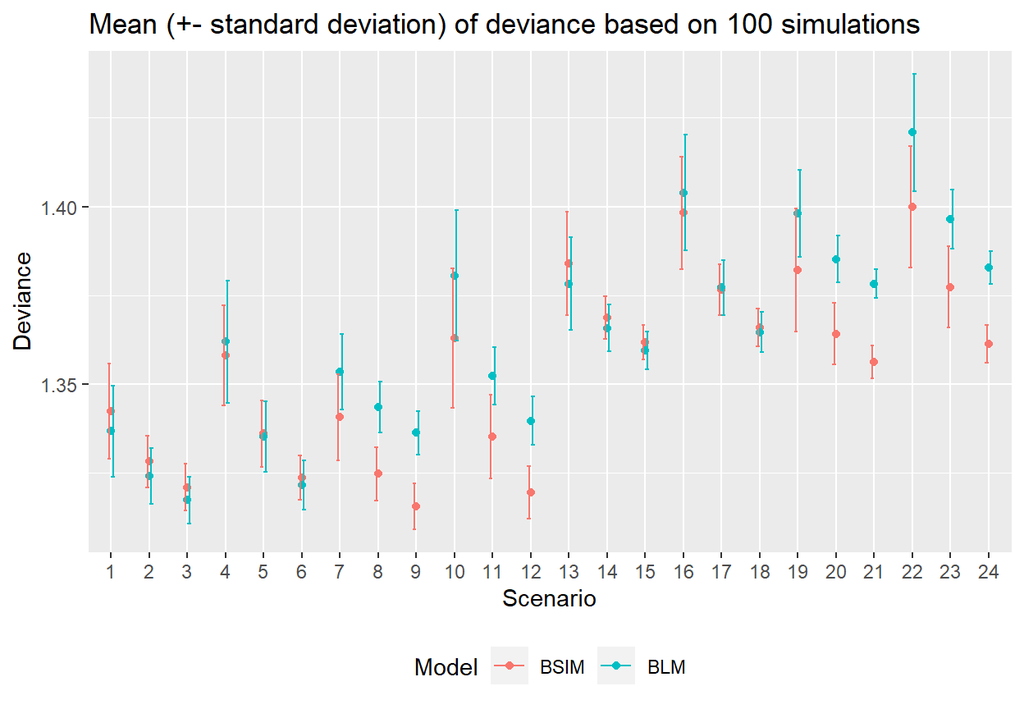

```r
m_dev <- results %>%
  group_by(replicate) %>%
  dplyr::summarise(mean_dev_bsim=mean(bsim.deviance), mean_dev_sng=mean(sng.bayes.deviance),
                   sd_dev_bsim=sd(bsim.deviance), sd_dev_sng=sd(sng.bayes.deviance))

l_dev <- reshape2::melt(m_dev,id=c("replicate"))
sd <- l_dev %>% subset(variable %in% c("sd_dev_sng","sd_dev_bsim"))
colnames(sd) <- c("replicate","variable_sd","value_sd")
mean_dev <- l_dev %>% subset(variable %in% c("mean_dev_bsim","mean_dev_sng"))
plot_dev <- cbind(mean_dev,sd[,-1])

plot_dev$replicate <- as.factor(plot_dev$replicate)

ggplot(plot_dev, aes(x=replicate, y=value, color=variable)) +
  geom_point()+
  geom_errorbar(aes(ymin=value - value_sd, ymax=value + value_sd), width=.2,
                position=position_dodge())+
  labs(title="Mean (+- standard deviation) of deviance based on 100 simulations",
        y = "Deviance", x= "Scenario")+ theme(legend.position="bottom")+
  scale_color_discrete(name = "Model", labels = c("BSIM", "BLM"))
```

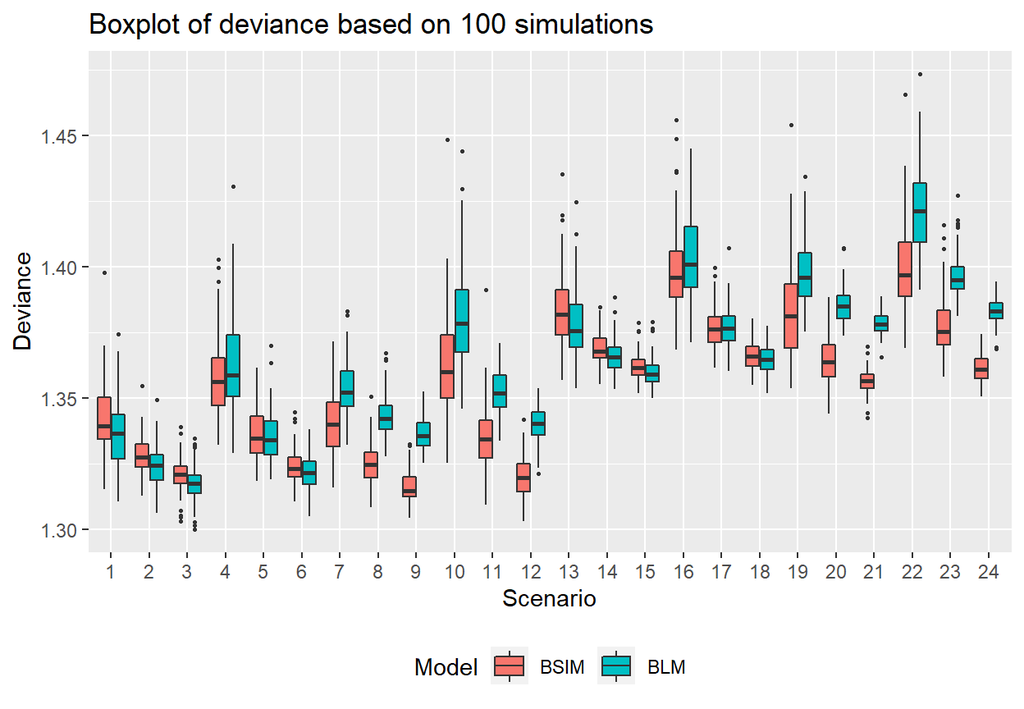

```r
dev <- results[,c("replicate","bsim.deviance","sng.bayes.deviance")]

dev <- reshape2::melt(dev,id=c("replicate"))
dev$replicate <- as.factor(dev$replicate)
ggplot(dev, aes(x=replicate, y=value,fill=variable)) +
  geom_boxplot(outlier.size=0.5)+
  labs(title="Boxplot of deviance based on 100 simulations",
        y = "Deviance", x= "Scenario")+ theme(legend.position="bottom")+
  scale_fill_discrete(name = "Model", labels = c("BSIM", "BLM"))
```

# 4 The expected outcome under the treatment regime

Different from the stan model(in iImulation_BSIMML_stan.html), the optimal treatment decision rule depends on the contrast:$\Delta = \beta_0+\boldsymbol{X_i}^\top\boldsymbol{\beta}$.

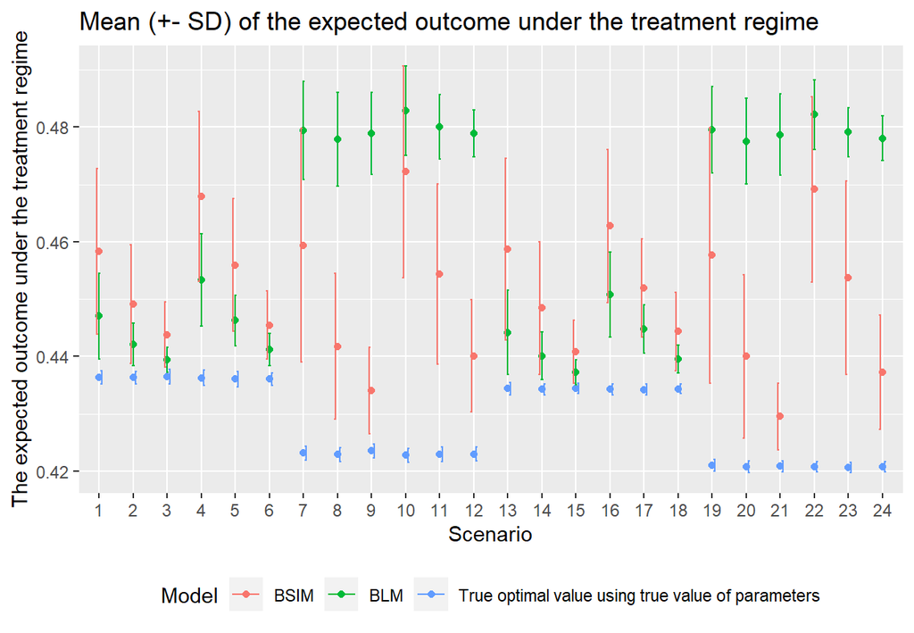

```r
m_e_y <- results %>%
  group_by(replicate) %>%
  dplyr::summarise(mean_y_bsim=mean(bsim.value), mean_y_sng=mean(sng.bayes.value),
                   mean_y_optim = mean(opt.value),
                   sd_y_bsim=sd(bsim.value), sd_y_sng=sd(sng.bayes.value),
                  sd_y_optim = sd(opt.value), )

l_y <- reshape2::melt(m_e_y,id=c("replicate"))
sd <- l_y %>% subset(variable %in% c("sd_y_sng","sd_y_bsim","sd_y_optim"))
colnames(sd) <- c("replicate","variable_sd","value_sd")
mean_y <- l_y %>% subset(variable %in% c("mean_y_bsim","mean_y_sng","mean_y_optim"))
plot_y <- cbind(mean_y,sd[,-1])

plot_y$replicate <- as.factor(plot_y$replicate)

ggplot(plot_y, aes(x=replicate, y=value, color=variable)) +
  geom_point()+
  geom_errorbar(aes(ymin=value - value_sd, ymax=value + value_sd), width=.2,
                position=position_dodge())+
  labs(title="Mean (+- SD) of the expected outcome under the treatment regime",
        y = "The expected outcome under the treatment regime", x= "Scenario")+ theme(legend.position="bottom")+
  scale_color_discrete(name = "Model", labels = c("BSIM", "BLM","True optimal value using true value of parameters"))
```

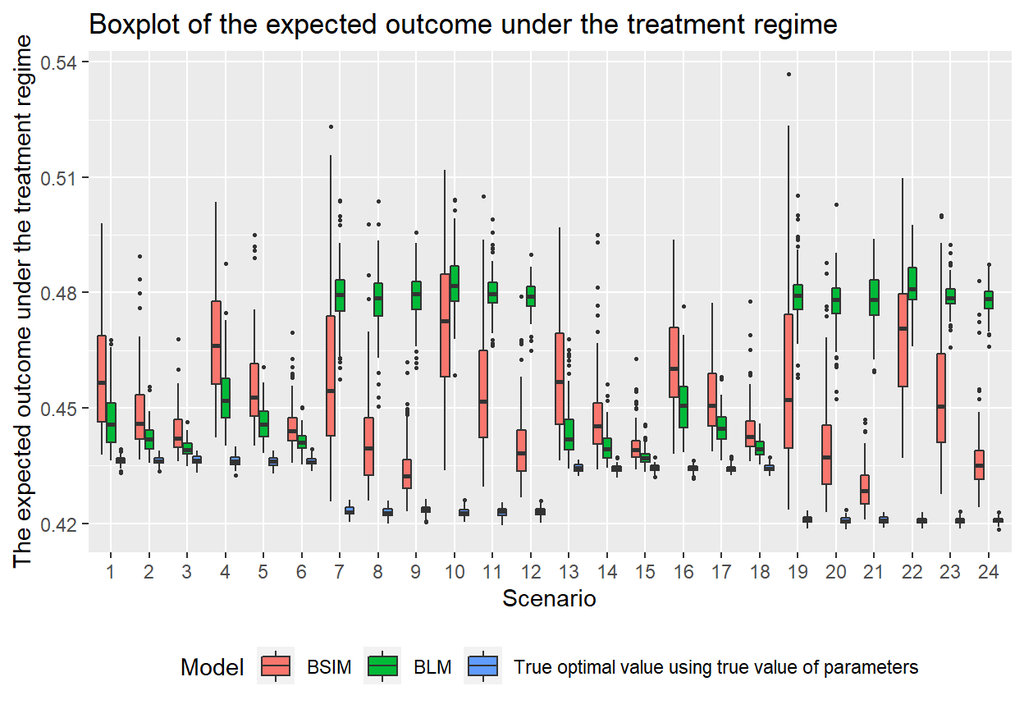

```r
e_y <- results[,c("replicate","bsim.value","sng.bayes.value","opt.value")]

e_y <- reshape2::melt(e_y,id=c("replicate"))
e_y$replicate <- as.factor(e_y$replicate)
ggplot(e_y, aes(x=replicate, y=value,fill=variable)) +
  geom_boxplot(outlier.size=0.5)+
  labs(title="Boxplot of the expected outcome under the treatment regime",
        y = "The expected outcome under the treatment regime", x= "Scenario")+ theme(legend.position="bottom")+
  scale_fill_discrete(name = "Model", labels = c("BSIM", "BLM","True optimal value using true value of parameters"))
```

# 5 PCD

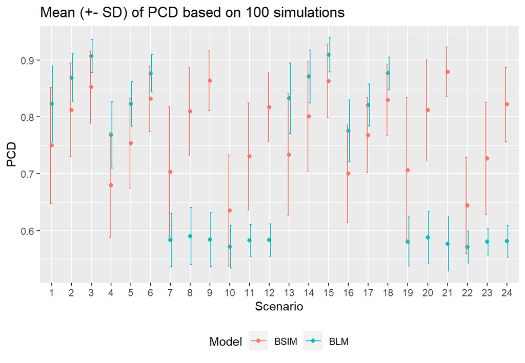

```r
m_pcd <- results %>%
  group_by(replicate) %>%
  dplyr::summarise(mean_pcd_bsim=mean(bsim.accuracy), mean_pcd_sng=mean(sng.bayes.accuracy),
                   sd_pcd_bsim=sd(bsim.accuracy), sd_pcd_sng=sd(sng.bayes.accuracy))

l_pcd <- reshape2::melt(m_pcd,id=c("replicate"))
sd <- l_pcd %>% subset(variable %in% c("sd_pcd_sng","sd_pcd_bsim"))
colnames(sd) <- c("replicate","variable_sd","value_sd")
mean_pcd <- l_pcd %>% subset(variable %in% c("mean_pcd_bsim","mean_pcd_sng"))
plot_pcd <- cbind(mean_pcd,sd[,-1])

plot_pcd$replicate <- as.factor(plot_pcd$replicate)

ggplot(plot_pcd, aes(x=replicate, y=value, color=variable)) +
  geom_point()+
  geom_errorbar(aes(ymin=value - value_sd, ymax=value + value_sd), width=.2,
                position=position_dodge())+
  labs(title="Mean (+- SD) of PCD based on 100 simulations",
        y = "PCD", x= "Scenario")+ theme(legend.position="bottom")+
  scale_color_discrete(name = "Model", labels = c("BSIM", "BLM"))
```

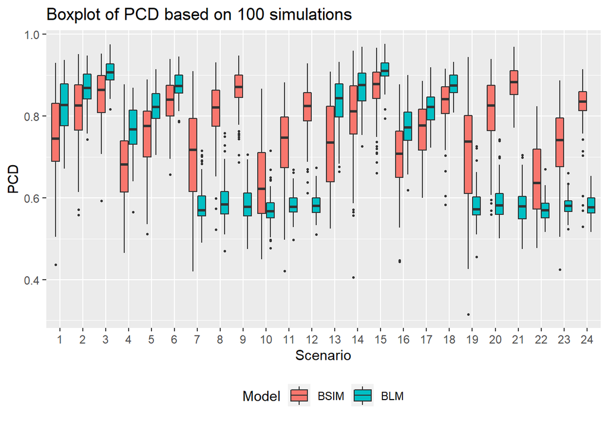

```r
pcd <- results[,c("replicate","bsim.accuracy","sng.bayes.accuracy")]

pcd <- reshape2::melt(pcd,id=c("replicate"))
pcd$replicate <- as.factor(pcd$replicate)
ggplot(pcd, aes(x=replicate, y=value,fill=variable)) +
  geom_boxplot(outlier.size=0.5)+
  labs(title="Boxplot of PCD based on 100 simulations",
        y = "PCD", x= "Scenario")+ theme(legend.position="bottom")+
  scale_fill_discrete(name = "Model", labels = c("BSIM", "BLM"))
```